# Final Project - Practical Machine Learning

#### Background

Using devices such as Jawbone Up, Nike FuelBand, and Fitbit it is now possible to collect a large amount of data about personal activity relatively inexpensively. These type of devices are part of the quantified self movement - a group of enthusiasts who take measurements about themselves regularly to improve their health, to find patterns in their behavior, or because they are tech geeks. One thing that people regularly do is quantify how much of a particular activity they do, but they rarely quantify how well they do it. In this project, the goal is to use data from accelerometers on the belt, forearm, arm, and dumbell of 6 participants. They were asked to perform barbell lifts correctly and incorrectly in 5 different ways. Based on this data we will be developing a model that will predict the quality of the exercise using test data provided as input.

#### Initializing Libraries and Reading the data from Source Site

```r
library(RCurl)
library(MASS)
library(stringr)
library(randomForest)
library(forecast)
library(ISLR)
library(lubridate)
library(caret)
library(dplyr)
library(magrittr)
library(rattle)
library(rpart.plot)
library(rpart)
library(compare)
setwd("C:/Data/R")
## Reading the data from Source Site
URLTrain <- "https://d396qusza40orc.cloudfront.net/predmachlearn/pml-training.csv"
x <- getURL(URLTrain)
TrainSet <- read.csv(textConnection(x),stringsAsFactors = F)
URLTest <- "https://d396qusza40orc.cloudfront.net/predmachlearn/pml-testing.csv"
y <- getURL(URLTest)
TestSet <- read.csv(textConnection(y),stringsAsFactors = F)
TrainSet$classe <- factor(TrainSet$classe)
```

#### Applying some data reorganizing and cleaning

```r
##Determine which variables are all null in test set to delete from train set
allmisscols <- apply(TestSet,2, function(x)all(is.na(x)))
## Clean test and train set and add the classe column back
TestSetClean <- TestSet[ ,!allmisscols]
TrainSetClean <- TrainSet[,!allmisscols]
TrainSetClean <- data.frame(TrainSetClean,TrainSet$classe)
##Eliminate useless columns in both sets
TrainSetClean <- TrainSetClean[, -c(1:7)]
TestSetClean[1,] <- TestSetClean[, -c(1:7)]
TrainSet2 <- TrainSetClean
TrainSet2 <- mutate_if(TrainSet2,is.character,as.factor)
```

#### Cross-validation in Trainset2 ***

```r
## Applying Cross-validation in Trainset2  ***
inTrain <- createDataPartition(y=TrainSet2$classe, p=0.7, list = FALSE)
training <- TrainSet2[inTrain,]
testing <- TrainSet2[-inTrain,]
```

#### * Running method rpart - Classification Model *****

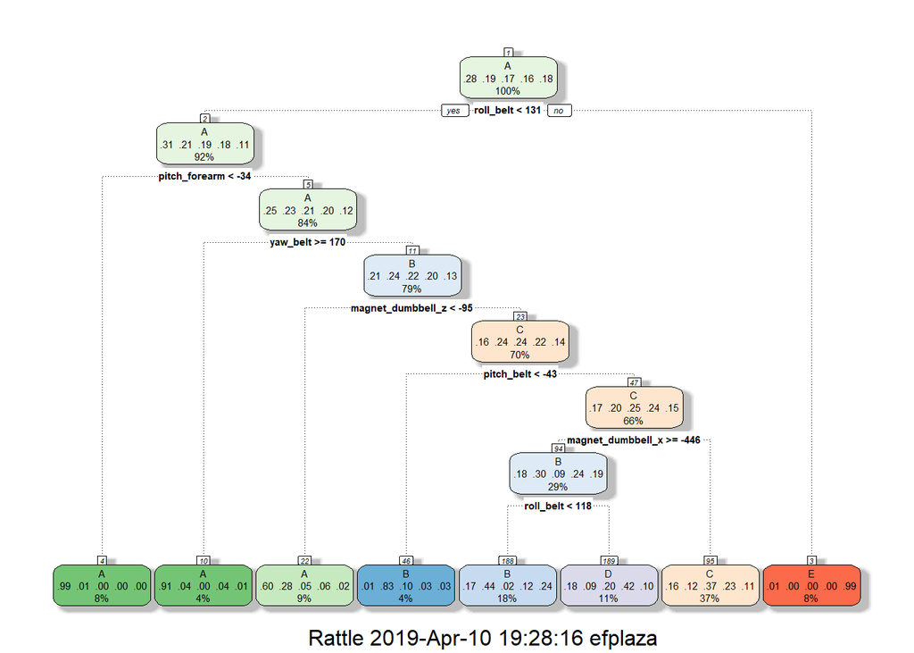

```r
setwd("C:/Data/R")
library(rattle)
library(rpart.plot)
library(rpart)
load("rpartfit.RData")
fancyRpartPlot(rpartfit$finalModel)
```

#### Checking the quality of the method rpart - Classification Model

```r
confusionMatrix(predict(rpartfit,testing),testing$classe)
```

```
## Confusion Matrix and Statistics
##
##           Reference
## Prediction    A    B    C    D    E
##          A 1002  170   25   44   14
##          B  177  655   46  137  260
##          C  366  245  821  516  269
##          D  123   69  134  267   59
##          E    6    0    0    0  480
##
## Overall Statistics
##
##                Accuracy : 0.548
##                  95% CI : (0.5352, 0.5608)
##     No Information Rate : 0.2845
##     P-Value [Acc > NIR] : < 2.2e-16
##
##                   Kappa : 0.4339
##  Mcnemar's Test P-Value : < 2.2e-16
##
## Statistics by Class:
##
##                      Class: A Class: B Class: C Class: D Class: E
## Sensitivity            0.5986   0.5751   0.8002  0.27697  0.44362
## Specificity            0.9399   0.8694   0.7127  0.92176  0.99875
## Pos Pred Value         0.7984   0.5137   0.3703  0.40951  0.98765
## Neg Pred Value         0.8549   0.8950   0.9441  0.86681  0.88850
## Prevalence             0.2845   0.1935   0.1743  0.16381  0.18386
## Detection Rate         0.1703   0.1113   0.1395  0.04537  0.08156
## Detection Prevalence   0.2133   0.2167   0.3767  0.11079  0.08258
## Balanced Accuracy      0.7692   0.7222   0.7564  0.59937  0.72119
```

#### * Running Random Forrest Model *****

```r
## modrf <- train(classe~.,method="rf",data=training, na.action = na.omit)
##save(modrf,file="modrf.RData")
setwd("C:/Data/R")
load("modrf.RData")
```